# 某品牌的广告投放效果

## 1、导入数据

```python
#调包
import pandas as pd
import numpy as np
import matplotlib.pyplot as plt
%matplotlib inline
import seaborn as sns

#读取数据表并查看其信息（若是guanggao.csv的目录不一样需要对下面目录位置进行修改）
data=pd.read_csv(r'C:\Users\asus\Desktop\陈尔毅简历\guanggao.csv')#目录位置需修改
data.drop([data.columns[0]],axis=1,inplace = True)
data.info()
```

```
<class 'pandas.core.frame.DataFrame'>
RangeIndex: 985 entries, 0 to 984
Data columns (total 7 columns):
 #   Column    Non-Null Count  Dtype
---  ------    --------------  -----
 0   revenue   985 non-null    float64
 1   reach     985 non-null    int64
 2   local_tv  929 non-null    float64
 3   online    985 non-null    int64
 4   instore   985 non-null    int64
 5   person    985 non-null    int64
 6   event     985 non-null    object
dtypes: float64(2), int64(4), object(1)
memory usage: 54.0+ KB
```

## 2、数据清洗

event数据类型为object需要对其进行转置。且发现local_tv有丢失数据,需要对统计数据的空值进行数据清洗

### 2.1 event数据转置

```python
#查看event数据有几种数据
data.event.unique()
```

```
array(['non_event', 'special', 'cobranding', 'holiday'], dtype=object)
```

```python
#将event数据变成哑变量
data_pd=pd.get_dummies(data)
data_pd.head()
```

|  | revenue | reach | local_tv | online | instore | person | event_cobranding | event_holiday | event_non_event | event_special |
| --- | --- | --- | --- | --- | --- | --- | --- | --- | --- | --- |
| 0 | 45860.28 | 2 | 31694.91 | 2115 | 3296 | 8 | 0 | 0 | 1 | 0 |
| 1 | 63588.23 | 2 | 35040.17 | 1826 | 2501 | 14 | 0 | 0 | 0 | 1 |
| 2 | 23272.69 | 4 | 30992.82 | 1851 | 2524 | 6 | 0 | 0 | 0 | 1 |
| 3 | 45911.23 | 2 | 29417.78 | 2437 | 3049 | 12 | 0 | 0 | 0 | 1 |
| 4 | 36644.23 | 2 | 35611.11 | 1122 | 1142 | 13 | 1 | 0 | 0 | 0 |

### 2.2 对空值进行数据清洗

```python
#查看空值的数量
data_pd.isnull().sum()
```

```
revenue              0
reach                0
local_tv            56
online               0
instore              0
person               0
event_cobranding     0
event_holiday        0
event_non_event      0
event_special        0
dtype: int64
```

从上面能够发现，local_tv有56个空值，需要对其进行数据填充

```python
#对local_tv的数据进行分析
data_pd.local_tv.describe()
```

```
count      929.000000
mean     31324.061109
std       3970.934733
min      20000.000000
25%      28733.830000
50%      31104.520000
75%      33972.410000
max      43676.900000
Name: local_tv, dtype: float64
```

因为local_tv均值与中位数的值接近，说明数据比较平均。所以local_tv的空值可用均值填充

```python
#用local_tv的均值填充local_tv的空值
data_pd=data_pd.fillna(data.mean())
data_pd.info()
```

```
<class 'pandas.core.frame.DataFrame'>
RangeIndex: 985 entries, 0 to 984
Data columns (total 10 columns):
 #   Column            Non-Null Count  Dtype
---  ------            --------------  -----
 0   revenue           985 non-null    float64
 1   reach             985 non-null    int64
 2   local_tv          985 non-null    float64
 3   online            985 non-null    int64
 4   instore           985 non-null    int64
 5   person            985 non-null    int64
 6   event_cobranding  985 non-null    uint8
 7   event_holiday     985 non-null    uint8
 8   event_non_event   985 non-null    uint8
 9   event_special     985 non-null    uint8
dtypes: float64(2), int64(4), uint8(4)
memory usage: 50.1 KB
```

## 3、相关性分析

查看数据分布

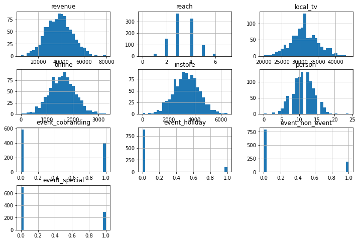

```python
#查看数据分布
data_pd.hist(bins=30,figsize=(12,8))
plt.show()
```

```python
#两两相关性分析
data_pd.corr()[['revenue']].sort_values('revenue',ascending=False)
```

|  | revenue |
| --- | --- |
| revenue | 1.000000 |
| local_tv | 0.588349 |
| person | 0.559208 |
| instore | 0.311739 |
| online | 0.171227 |
| event_special | 0.033752 |
| event_cobranding | -0.005623 |
| event_holiday | -0.016559 |
| event_non_event | -0.019155 |
| reach | -0.155314 |

能够发现里面有local_tv、person、instore这三个变量与revenue的相关性比较强，因此对这三个变量进行分析。

### 3.1查看单变量的相关性

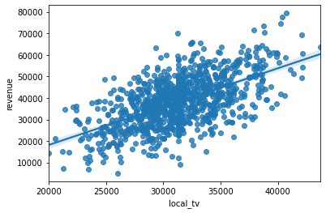

```python
#对local_tv这个变量进行分析
sns.regplot('local_tv','revenue',data_pd)
```

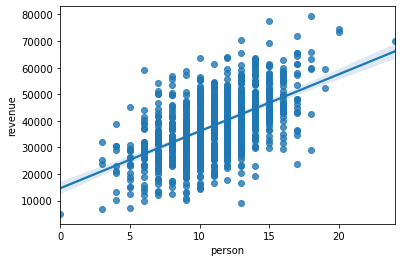

```python
#对person这个变量进行分析
sns.regplot('person','revenue',data_pd)
```

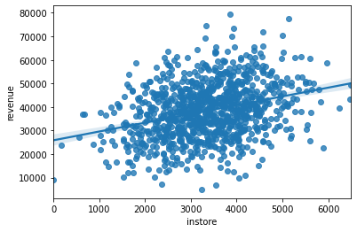

```python
#对instore这个变量进行分析
sns.regplot('instore','revenue',data_pd)
```

通过以上的对单变量的分析，我们能够发现，广告投入与销售额还是有一定的正相关，但是还需要对其进行线性回归分析，才能得到具体正相关的关系。

## 4、线性回归分析

```python
#线性回归分析
#调包
from sklearn.linear_model import LinearRegression

#建模
model=LinearRegression()

#设定因变量为revenue
y=data_pd['revenue']
#设定自变量为local_tv、person、instore
x=data_pd[['local_tv','person','instore']]

#建立模型
model.fit(x,y)
```

```
LinearRegression()
```

```python
#自变量系数
model.coef_
```

```
array([1.75153812e+00, 2.05057495e+03, 4.09032709e+00])
```

```python
#模型的截距
model.intercept_
```

```
-52881.12439058924
```

对于上述的模型，需要对其进行模型的评估，看看是否需要优化。

## 5、模型评估与优化

```python
#对model模型进行打分
score=model.score(x,y)

#计算其误差值大小
y_predict=model.predict(x)
y_error=y_predict-y

#计算mae（平均绝对误差）和rmse（均方根差）
mae=abs(y_error).mean()
rmse=(y_error**2).mean()**.5

print('mae为：',mae)
print('rmse为：',rmse)
```

```
mae为： 4717.8947664817115
rmse为： 5884.181391972567
```

为了提升模型的准确性，把online的变量加入。因此重新建立模型

```python
#建模
model_fix=LinearRegression()

#设定因变量为revenue
y_fix=data_pd['revenue']
#设定自变量为local_tv、person、instore
x_fix=data_pd[['local_tv','person','instore','online']]

#建立模型
model_fix.fit(x_fix,y_fix)
```

```
LinearRegression()
```

```python
#新模型自变量系数
model_fix.coef_
```

```
array([1.74975212e+00, 2.02868682e+03, 4.13909283e+00, 3.69796299e+00])
```

```python
#新模型的截距
model_fix.intercept_
```

```
-58650.545689191895
```

```python
#对新模型进行打分
score_fix=model_fix.score(x_fix,y_fix)

#计算其误差值大小
y_predict_fix=model_fix.predict(x_fix)
y_error_fix=y_predict_fix-y_fix

#计算mae（平均绝对误差）和rmse（均方根差）
mae=abs(y_error_fix).mean()
rmse=(y_error_fix**2).mean()**.5

print('mae为：',mae)
print('rmse为：',rmse)
```

```
mae为： 4485.506383110859
rmse为： 5591.764749668997
```

能够发现在person的投入提升收入的效果更好，每投入1元能够提升2028元的销售额， 对于相关性较强的local_tv,每提升1元的local_tv投入，可以得到1.75元的销售额回报。

## 6、数据分析结论

对销售人员宣传的投入提升能够快速提升销售额，广告宣传效果最好的是本地电视广告，它很大程度上在影响销售额。但是由于本组数据有许多混杂因素（local_tv、person、instore等因素均会影响销售额），无法对单变量进行一一分析，无法量化该投入具体多少金额给本地电视广告、销售人员、店内宣传，因此本次数据分析暂时不对其进行量化。